# Read in the data

```python
import pandas as pd
import numpy
import re

data_files = [
    "ap_2010.csv",
    "class_size.csv",
    "demographics.csv",
    "graduation.csv",
    "hs_directory.csv",
    "sat_results.csv"
]

data = {}

for f in data_files:
    d = pd.read_csv("schools/{0}".format(f))
    data[f.replace(".csv", "")] = d
```

# Read in the surveys

```python
all_survey = pd.read_csv("schools/survey_all.txt", delimiter="\t", encoding='windows-1252')
d75_survey = pd.read_csv("schools/survey_d75.txt", delimiter="\t", encoding='windows-1252')
survey = pd.concat([all_survey, d75_survey], axis=0)

survey["DBN"] = survey["dbn"]

survey_fields = [
    "DBN",
    "rr_s",
    "rr_t",
    "rr_p",
    "N_s",
    "N_t",
    "N_p",
    "saf_p_11",
    "com_p_11",
    "eng_p_11",
    "aca_p_11",
    "saf_t_11",
    "com_t_11",
    "eng_t_11",
    "aca_t_11",
    "saf_s_11",
    "com_s_11",
    "eng_s_11",
    "aca_s_11",
    "saf_tot_11",
    "com_tot_11",
    "eng_tot_11",
    "aca_tot_11",
]
survey = survey.loc[:,survey_fields]
data["survey"] = survey
```

# Add DBN columns

```python
data["hs_directory"]["DBN"] = data["hs_directory"]["dbn"]

def pad_csd(num):
    string_representation = str(num)
    if len(string_representation) > 1:
        return string_representation
    else:
        return "0" + string_representation

data["class_size"]["padded_csd"] = data["class_size"]["CSD"].apply(pad_csd)
data["class_size"]["DBN"] = data["class_size"]["padded_csd"] + data["class_size"]["SCHOOL CODE"]
```

# Convert columns to numeric

```python
cols = ['SAT Math Avg. Score', 'SAT Critical Reading Avg. Score', 'SAT Writing Avg. Score']
for c in cols:
    data["sat_results"][c] = pd.to_numeric(data["sat_results"][c], errors="coerce")

data['sat_results']['sat_score'] = data['sat_results'][cols[0]] + data['sat_results'][cols[1]] + data['sat_results'][cols[2]]

def find_lat(loc):
    coords = re.findall("\(.+, .+\)", loc)
    lat = coords[0].split(",")[0].replace("(", "")
    return lat

def find_lon(loc):
    coords = re.findall("\(.+, .+\)", loc)
    lon = coords[0].split(",")[1].replace(")", "").strip()
    return lon

data["hs_directory"]["lat"] = data["hs_directory"]["Location 1"].apply(find_lat)
data["hs_directory"]["lon"] = data["hs_directory"]["Location 1"].apply(find_lon)

data["hs_directory"]["lat"] = pd.to_numeric(data["hs_directory"]["lat"], errors="coerce")
data["hs_directory"]["lon"] = pd.to_numeric(data["hs_directory"]["lon"], errors="coerce")
```

# Condense datasets

```python
class_size = data["class_size"]
class_size = class_size[class_size["GRADE "] == "09-12"]
class_size = class_size[class_size["PROGRAM TYPE"] == "GEN ED"]

class_size = class_size.groupby("DBN").agg(numpy.mean)
class_size.reset_index(inplace=True)
data["class_size"] = class_size

data["demographics"] = data["demographics"][data["demographics"]["schoolyear"] == 20112012]

data["graduation"] = data["graduation"][data["graduation"]["Cohort"] == "2006"]
data["graduation"] = data["graduation"][data["graduation"]["Demographic"] == "Total Cohort"]
```

# Convert AP scores to numeric

```python
cols = ['AP Test Takers ', 'Total Exams Taken', 'Number of Exams with scores 3 4 or 5']

for col in cols:
    data["ap_2010"][col] = pd.to_numeric(data["ap_2010"][col], errors="coerce")
```

# Combine the datasets

```python
combined = data["sat_results"]

combined = combined.merge(data["ap_2010"], on="DBN", how="left")
combined = combined.merge(data["graduation"], on="DBN", how="left")

to_merge = ["class_size", "demographics", "survey", "hs_directory"]

for m in to_merge:
    combined = combined.merge(data[m], on="DBN", how="inner")

combined = combined.fillna(combined.mean())
combined = combined.fillna(0)
```

# Add a school district column for mapping

```python
def get_first_two_chars(dbn):
    return dbn[0:2]

combined["school_dist"] = combined["DBN"].apply(get_first_two_chars)
```

# Find correlations

```python
correlations = combined.corr()
correlations = correlations["sat_score"]
print(correlations)
```

```
SAT Critical Reading Avg. Score         0.987177
SAT Math Avg. Score                     0.974189
SAT Writing Avg. Score                  0.987580
sat_score                               1.000000
AP Test Takers                          0.533062
Total Exams Taken                       0.527895
Number of Exams with scores 3 4 or 5    0.476988
Total Cohort                            0.369079
CSD                                    -0.277203
NUMBER OF STUDENTS / SEATS FILLED       0.460160
NUMBER OF SECTIONS                      0.425677
AVERAGE CLASS SIZE                      0.340298
SIZE OF SMALLEST CLASS                  0.256287
SIZE OF LARGEST CLASS                   0.272362
SCHOOLWIDE PUPIL-TEACHER RATIO               NaN
schoolyear                                   NaN
fl_percent                                   NaN
frl_percent                            -0.714024
total_enrollment                        0.421149
ell_num                                -0.199897
ell_percent                            -0.385768
sped_num                               -0.066046
sped_percent                           -0.432525
asian_num                               0.526216
asian_per                               0.601428
black_num                               0.032064
black_per                              -0.237382
hispanic_num                            0.013096
hispanic_per                           -0.368352
white_num                               0.566020
                                          ...
N_s                                     0.490393
N_t                                     0.307905
N_p                                     0.442561
saf_p_11                                0.092439
com_p_11                               -0.108462
eng_p_11                                0.011771
aca_p_11                                0.042359
saf_t_11                                0.272638
com_t_11                                0.033666
eng_t_11                               -0.004906
aca_t_11                                0.091019
saf_s_11                                0.288688
com_s_11                                0.171808
eng_s_11                                0.164229
aca_s_11                                0.307206
saf_tot_11                              0.272961
com_tot_11                              0.044631
eng_tot_11                              0.053516
aca_tot_11                              0.150869
grade_span_max                               NaN
expgrade_span_max                            NaN
zip                                    -0.212338
total_students                          0.469879
number_programs                         0.064500
priority07                                   NaN
priority08                                   NaN
priority09                                   NaN
priority10                                   NaN
lat                                    -0.053500
lon                                    -0.296314
Name: sat_score, Length: 68, dtype: float64
```

# Plotting survey correlations

```python
# Remove DBN since it's a unique identifier, not a useful numerical value for correlation.
survey_fields.remove("DBN")
```

```python
%matplotlib inline
```

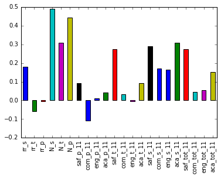

```python
combined.corr()['sat_score'][survey_fields].plot.bar()
```

There appear to be correlations between N_s, N_t and N_p. These just relate to the number of respondents, so may not show us too much.

There is a correlation with rr_s, which still doesn't seem to show us too much.

The correlation with saf_t_11, saf_s_11 and saf_tot_11 seem to indicate that perceived safety and respect relate to SAT scores.

The correlation with aca_s_11 indicates that the academic expectations of the students correlated to SAT scores, but not necessarily if the teachs had the expectation.

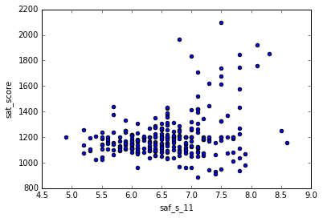

```python
combined.plot.scatter('saf_s_11', 'sat_score')
```

It appears that SAT scores generally don't change below 6.5 ratings, but above that rating, they begin to go up.

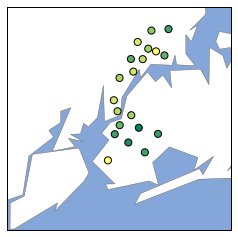

```python
import matplotlib.pyplot as plt
from mpl_toolkits.basemap import Basemap

districts = combined.groupby("school_dist").agg(numpy.mean)
districts.reset_index(inplace=True)

m = Basemap(
    projection='merc',
    llcrnrlat=40.496044,
    urcrnrlat=40.915256,
    llcrnrlon=-74.255735,
    urcrnrlon=-73.700272,
    resolution='i'
)

m.drawmapboundary(fill_color='#85A6D9')
m.drawcoastlines(color='#6D5F47', linewidth=.4)
m.drawrivers(color='#6D5F47', linewidth=.4)
m.fillcontinents(color='white',lake_color='#85A6D9')

longitudes = districts["lon"].tolist()
latitudes = districts["lat"].tolist()
m.scatter(longitudes, latitudes, s=50, zorder=2, latlon=True, c=districts["saf_s_11"], cmap="summer")
plt.show()
```

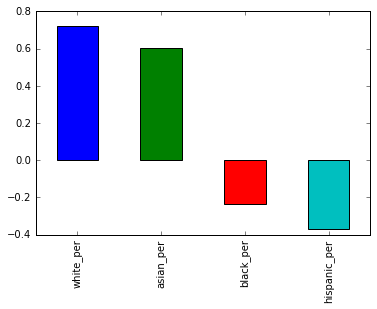

```python
combined.corr()['sat_score'][['white_per','asian_per','black_per','hispanic_per']].plot.bar()
```

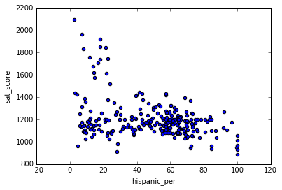

```python
combined.plot.scatter('hispanic_per','sat_score')
```

It seems to be a negative correlation, but levels out largely when the hispanic population goes above 25%

```python
print(combined[combined['hispanic_per'] > 95]['SCHOOL NAME'])
```

```
44                         MANHATTAN BRIDGES HIGH SCHOOL
82      WASHINGTON HEIGHTS EXPEDITIONARY LEARNING SCHOOL
89     GREGORIO LUPERON HIGH SCHOOL FOR SCIENCE AND M...
125                  ACADEMY FOR LANGUAGE AND TECHNOLOGY
141                INTERNATIONAL SCHOOL FOR LIBERAL ARTS
176     PAN AMERICAN INTERNATIONAL HIGH SCHOOL AT MONROE
253                            MULTICULTURAL HIGH SCHOOL
Name: SCHOOL NAME, dtype: object
```

These schools are focused on international students. These students may just have a harder time understanding English, causing a barrier when taking a standardized test.

```python
print(combined[(combined['hispanic_per'] < 10) & (combined['sat_score'] > 1800)]['SCHOOL NAME'])
```

```
37             STUYVESANT HIGH SCHOOL
151      BRONX HIGH SCHOOL OF SCIENCE
187    BROOKLYN TECHNICAL HIGH SCHOOL
Name: SCHOOL NAME, dtype: object
```

These schools have a high expectation before admitting students. It makes sense that the scores are higher for this reason.

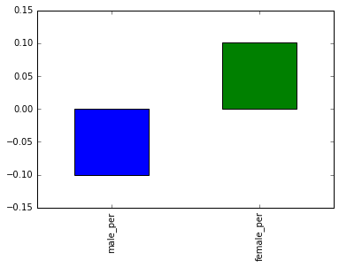

```python
combined.corr()['sat_score'][['male_per','female_per']].plot.bar()
```

More women means a higher score. Less men means a higher score.

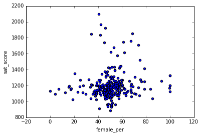

```python
combined.plot.scatter('female_per','sat_score')
```

```python
print(combined[(combined['female_per'] > 60) & (combined['sat_score'] > 1700)]['SCHOOL NAME'])
```

```
5                        BARD HIGH SCHOOL EARLY COLLEGE
26                        ELEANOR ROOSEVELT HIGH SCHOOL
60                                   BEACON HIGH SCHOOL
61    FIORELLO H. LAGUARDIA HIGH SCHOOL OF MUSIC & A...
Name: SCHOOL NAME, dtype: object
```

There doesn't seem to be a true correlation between percent of women and the high scores. The high scores are situated near the middle. Perhaps this indicates just programs that try to keep it even.

```python
combined['ap_per'] = combined['AP Test Takers '] / combined['total_enrollment']
```

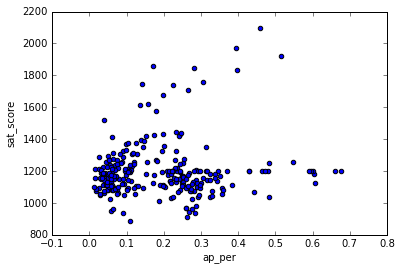

```python
combined.plot.scatter('ap_per','sat_score')
```

There again doesn't really seem to be a correlation between the percentage of students that took AP exams and the SAT score.